# Risk factors in accidental drug related deaths.

## 0.1 Preliminaries

```r
library(forcats)
library(broom)
library(skimr)
library(modelr)
library(Hmisc)
library(tidyverse)
library(tableone)
library(ROCR)
library(magrittr)
library(MASS)
library(rms)
```

# 1 Task-1 Data Source

Accidental Drug Related Deaths 2012-June 2017 in Connecticut (CT). This data set is readily available at the following website, which is open for all the public users. https://catalog.data.gov/dataset/accidental-drug-related-deaths-january-2012-sept-2015/resource/44580a89-a260-4844-8ead-35736f395389

Accidental Drug Related Deaths are increasing in USA. This dataset contains information regarding multiple drug overdose related accidents form 2012 - June 2017 in Connecticut area. A “Y” value under the different substance columns indicates that particular substance was detected in the person. Data are derived from an investigation by the Office of the Chief Medical Examiner which includes the toxicity report, death certificate, as well as a scene investigation.

In this study, I am planning to evaluate if I can predict age of an individual ( continuous variable )in drug overdose related accidents using linear regression model.

In another part of the study, I will see if odds ratio of Alcohol consumption is different among the different drug (Heroin, cocaine, fentanyl, oxycodone,oxymorphone) overdose related accidents . An alcohol could complicating factor with one of these drugs listed. I want to evaluate if drug overdose related accidents are more common in alcohol drinkers. The original dataset had several other drugs. However, I restrict my study on major drugs, which are Heroin, Cocaine, Fentanyl, Oxycodone, Oxymorphone and Alcohol.

# 2 Task-2 Load and tidy the dataset

```r
project_1<-read.csv("Accidental_Drug_related_deaths-2.csv", stringsAsFactors=FALSE)%>%tbl_df()
project_1$Heroin<-fct_recode(project_1$Heroin,
           Y = "y",
           N = "",
           N2 = " ")
project_1$Heroin<-fct_recode(project_1$Heroin,
           N = "N2")
project_1$Cocaine<-fct_recode(project_1$Cocaine,
           Y = "y",
           N = "")
project_1$Fentanyl<-fct_recode(project_1$Fentanyl,
           Y = "y",
           Y1="Y ",
           N = "")
project_1$Fentanyl<-fct_recode(project_1$Fentanyl,
           Y = "Y1")
project_1$Oxycodone<-fct_recode(project_1$Oxycodone,
           Y = "y",
           N = "")
project_1$Oxymorphone<-fct_recode(project_1$Oxymorphone,
           Y = "y",
           N = "")
project_1$Alcohol<-fct_recode(project_1$Alcohol,
           Y = "y",
           N = "")
project_1
```

```
# A tibble: 999 x 13
   CaseNumber       Date    Sex            Race   Age  Death_City
        <chr>      <chr>  <chr>           <chr> <int>       <chr>
 1   13-16336  11/9/2013 Female           White    53      GROTON
 2   12-18447 12/29/2012   Male           White    30   WATERBURY
 3    14-2758  2/18/2014   Male           White    43     ENFIELD
 4   14-13497   9/7/2014 Female           White    24 WALLINGFORD
 5   13-14421  10/4/2013 Female           White    26  WEST HAVEN
 6   13-18018 12/10/2013 Female           White    45     DANBURY
 7   13-19004 12/27/2013   Male           White    55  BRIDGEPORT
 8    13-3783   3/4/2013   Male Hispanic, White    47   NEW HAVEN
 9    14-5669   4/9/2014 Female           White    53     DANBURY
10    13-9675  6/28/2013   Male           White    29   WATERBURY
# ... with 989 more rows, and 7 more variables: Location <chr>,
#   Heroin <fctr>, Cocaine <fctr>, Fentanyl <fctr>, Oxycodone <fctr>,
#   Oxymorphone <fctr>, Alcohol <fctr>
```

```r
project_1$Location<-fct_recode(project_1$Location)
project_1$Death_City<-fct_recode(project_1$Death_City)
project_1$Race<-fct_recode(project_1$Race,
           Black = "Hispanic, Black")
          project_1$Sex<-fct_recode(project_1$Sex)
project_1
```

```
# A tibble: 999 x 13
   CaseNumber       Date    Sex            Race   Age  Death_City
        <chr>      <chr> <fctr>          <fctr> <int>      <fctr>
 1   13-16336  11/9/2013 Female           White    53      GROTON
 2   12-18447 12/29/2012   Male           White    30   WATERBURY
 3    14-2758  2/18/2014   Male           White    43     ENFIELD
 4   14-13497   9/7/2014 Female           White    24 WALLINGFORD
 5   13-14421  10/4/2013 Female           White    26  WEST HAVEN
 6   13-18018 12/10/2013 Female           White    45     DANBURY
 7   13-19004 12/27/2013   Male           White    55  BRIDGEPORT
 8    13-3783   3/4/2013   Male Hispanic, White    47   NEW HAVEN
 9    14-5669   4/9/2014 Female           White    53     DANBURY
10    13-9675  6/28/2013   Male           White    29   WATERBURY
# ... with 989 more rows, and 7 more variables: Location <fctr>,
#   Heroin <fctr>, Cocaine <fctr>, Fentanyl <fctr>, Oxycodone <fctr>,
#   Oxymorphone <fctr>, Alcohol <fctr>
```

There are total 13 variables(column) in the dataset with 999(rows) observations. There was only one “black hispanic race”" individual, I recode it as “Black”.

# 3 Task 3: Listing of My Tibble

```r
summary(project_1)
```

```
  CaseNumber            Date               Sex
 Length:999         Length:999         Female:290
 Class :character   Class :character   Male  :709
 Mode  :character   Mode  :character




                  Race          Age             Death_City
 Asian,other,unknown: 14   Min.   :14.00   HARTFORD  : 89
 Black              : 68   1st Qu.:31.00   WATERBURY : 81
 Hispanic, White    :101   Median :42.00   NEW HAVEN : 76
 White              :816   Mean   :41.72   BRIDGEPORT: 62
                           3rd Qu.:51.00   NEW LONDON: 44
                           Max.   :75.00   (Other)   :646
                                           NA's      :  1
      Location   Heroin  Cocaine Fentanyl Oxycodone Oxymorphone Alcohol
          :  2   N:322   N:725   N:864    N:820     N:948       N:483
 Hospital :345   Y:677   Y:274   Y:135    Y:179     Y: 51       Y:516
 Other    :145
 Residence:505
 NA's     :  2
```

```r
map_df(project_1, function(x) sum(is.na(x)))
```

```
# A tibble: 1 x 13
  CaseNumber  Date   Sex  Race   Age Death_City Location Heroin Cocaine
       <int> <int> <int> <int> <int>      <int>    <int>  <int>   <int>
1          0     0     0     0     0          1        2      0       0
# ... with 4 more variables: Fentanyl <int>, Oxycodone <int>,
#   Oxymorphone <int>, Alcohol <int>
```

There are total of 13 variables (columns) in the dataset with 999 (rows) observations (rows). There is 1 observation missing the variable `death city` and 2 missing `death location`s. These variables are not likely to truly impact my analyses, as I do not plan to undertake an anlaysis based on geographic location. Therefore, to finalize the variables and simplify the dataset, the variables `Location` and `Death_City` were deleted from the dataset.

```r
project_1F <- subset( project_1, select = -c(Location, Death_City ) )
project_1F
```

```
# A tibble: 999 x 11
   CaseNumber       Date    Sex            Race   Age Heroin Cocaine
        <chr>      <chr> <fctr>          <fctr> <int> <fctr>  <fctr>
 1   13-16336  11/9/2013 Female           White    53      N       N
 2   12-18447 12/29/2012   Male           White    30      N       Y
 3    14-2758  2/18/2014   Male           White    43      N       N
 4   14-13497   9/7/2014 Female           White    24      Y       N
 5   13-14421  10/4/2013 Female           White    26      Y       N
 6   13-18018 12/10/2013 Female           White    45      Y       N
 7   13-19004 12/27/2013   Male           White    55      Y       N
 8    13-3783   3/4/2013   Male Hispanic, White    47      Y       Y
 9    14-5669   4/9/2014 Female           White    53      N       Y
10    13-9675  6/28/2013   Male           White    29      Y       N
# ... with 989 more rows, and 4 more variables: Fentanyl <fctr>,
#   Oxycodone <fctr>, Oxymorphone <fctr>, Alcohol <fctr>
```

```r
project_1F <- project_1F %>%
    mutate(
        Race2 = factor(case_when(
            Race == "White" ~ "1",
            Race ==" White"~"1",
            Race == "Hispanic, White" ~ "2",
            Race == " Hispanic, White" ~ "2",
            Race == "Black" ~ "3",
            Race == "Asian,other,unknown" ~ "4")))
project_1F
```

```
# A tibble: 999 x 12
   CaseNumber       Date    Sex            Race   Age Heroin Cocaine
        <chr>      <chr> <fctr>          <fctr> <int> <fctr>  <fctr>
 1   13-16336  11/9/2013 Female           White    53      N       N
 2   12-18447 12/29/2012   Male           White    30      N       Y
 3    14-2758  2/18/2014   Male           White    43      N       N
 4   14-13497   9/7/2014 Female           White    24      Y       N
 5   13-14421  10/4/2013 Female           White    26      Y       N
 6   13-18018 12/10/2013 Female           White    45      Y       N
 7   13-19004 12/27/2013   Male           White    55      Y       N
 8    13-3783   3/4/2013   Male Hispanic, White    47      Y       Y
 9    14-5669   4/9/2014 Female           White    53      N       Y
10    13-9675  6/28/2013   Male           White    29      Y       N
# ... with 989 more rows, and 5 more variables: Fentanyl <fctr>,
#   Oxycodone <fctr>, Oxymorphone <fctr>, Alcohol <fctr>, Race2 <fctr>
```

```r
str(project_1F)
```

```
Classes 'tbl_df', 'tbl' and 'data.frame':   999 obs. of  12 variables:
 $ CaseNumber : chr  "13-16336" "12-18447" "14-2758" "14-13497" ...
 $ Date       : chr  "11/9/2013" "12/29/2012" "2/18/2014" "9/7/2014" ...
 $ Sex        : Factor w/ 2 levels "Female","Male": 1 2 2 1 1 1 2 2 1 2 ...
 $ Race       : Factor w/ 4 levels "Asian,other,unknown",..: 4 4 4 4 4 4 4 3 4 4 ...
 $ Age        : int  53 30 43 24 26 45 55 47 53 29 ...
 $ Heroin     : Factor w/ 2 levels "N","Y": 1 1 1 2 2 2 2 2 1 2 ...
 $ Cocaine    : Factor w/ 2 levels "N","Y": 1 2 1 1 1 1 1 2 2 1 ...
 $ Fentanyl   : Factor w/ 2 levels "N","Y": 1 1 1 2 1 1 1 1 1 2 ...
 $ Oxycodone  : Factor w/ 2 levels "N","Y": 2 2 1 1 1 1 1 1 1 1 ...
 $ Oxymorphone: Factor w/ 2 levels "N","Y": 2 1 1 1 1 1 1 1 1 1 ...
 $ Alcohol    : Factor w/ 2 levels "N","Y": 1 1 2 2 2 2 2 2 1 2 ...
 $ Race2      : Factor w/ 4 levels "1","2","3","4": 1 1 1 1 1 1 1 2 1 1 ...
```

# 4 Task-4 Code book

| Variable | Type | Details |
| --- | --- | --- |
| `Case Number` | character | Drug overdose related deaths identification code |
| `Date` | character | the date on which person died due to drug overdose (mm/dd/YYYY) |
| `Sex` | binary | sex (female, male) of a person died |
| `Race` | multi-categorical | Race of a dead person (white=1, hispanic white=2, black or hispanic black=3, Asian and other=4) |
| `Age` | quantitative | Person’s age at death |
| `Heroin` | binary | person intoxicated with heroin at the time of death Y=Yes, N= No |
| `Cocaine` | binary | person intoxicated with Cocaine at the time of death Y=Yes,N= No |
| `Fentanyl` | binary | person intoxicated with Fentanyl at the time of death Y=Yes,N= No |
| `Oxycodone` | binary | person intoxicated with Oxycodone at the time of death Y=Yes,N= No |
| `Oxymorphone` | binary | person intoxicated with Oxymorphone at the time of death Y=Yes, N= No |
| `Alcohol` | binary | person intoxicated with Alcohol at the time of death Y=Yes, N= No |

# 5 Task 5: My Subjects

There are 999 rows in the dataset. Each row describes a person who died due to drug overdose in the Connecticut area between 2012-2015.

# 6 Task 6: My Variables

There are total 11 variables(column) in the dataset with 999(rows) observations.

1. CaseNumber This is a person’s identification code.
2. Date This is the day when person died due to drug overdose or substance abuse (mm/dd/YYYY). 3.Sex This is a gender female and male died due to drug overdose or substance abuse.
3. Race This is the person’s race.
4. Age Age of the person at the time of death (in years).
5. Heroin Person intoxicated with heroin at the time of death Y=Yes, N= No
6. Cocaine Person intoxicated with cocaine at the time of death Y=Yes, N= No
7. Fentanyl Person intoxicated with fentanyl at the time of death Y=Yes, N= No
8. Oxycodone Person intoxicated with Oxycodone at the time of death Y=Yes, N= No
9. Oxymorphone Person intoxicated with Oxymorphone at the time of death Y=Yes, N= No 11.Alcohol Person intoxicated with alcohol at the time of death Y=Yes, N= No

# 7 Task-7 Linear Regression Model

Predict the quantitative outcome Age using some combination of the following seven variables:

1. Race
2. Sex
3. Heroin
4. Cocaine
5. Fentanyl
6. Oxymorphone
7. Alcohol

# 8 Task-8 Logistic Regression model

Predict the binary outcome Alcohol using some combination of the following seven variables:

1. Race
2. Sex
3. Heroin
4. cocaine
5. Fentanyl
6. Oxycodone
7. Oxymorphone

# 9 Task 9: Affirmation

This data set meets almost all requirements specified in the project instructions. This dataset describes 999 deaths due to substance abuse or drug overdose.  
I am considering atleat seven predictors for each regression model, and include at least one quantitative (Age) and Race as a multi-categorical variable in each model. This dataset can be shared with anyone without any conditions.

# 10 Task-10 Linear Regression Model

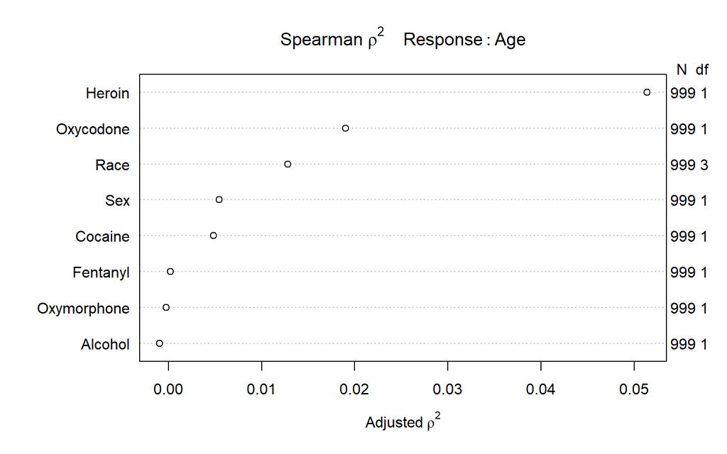

```r
plot(spearman2(Age ~ Race+Sex+Heroin+Cocaine+Fentanyl+Oxymorphone+Oxycodone+Alcohol, data=project_1F))
```

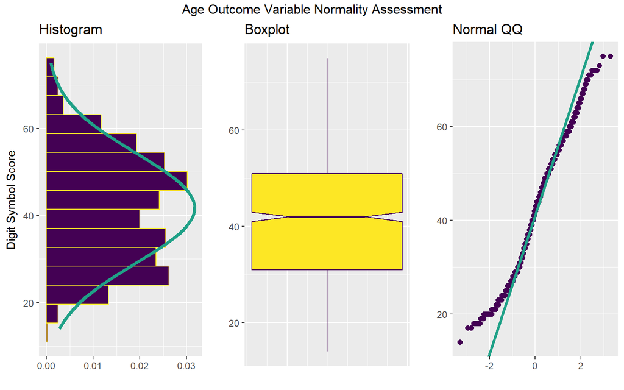

```r
source("Love-boost.R")
eda.1sam(dataframe= project_1F,
         variable=project_1F$Age,
         x.title="Digit Symbol Score",
         ov.title="Age Outcome Variable Normality Assessment")
```

Output age is fairly normally distributed, however distribution is not perfect.

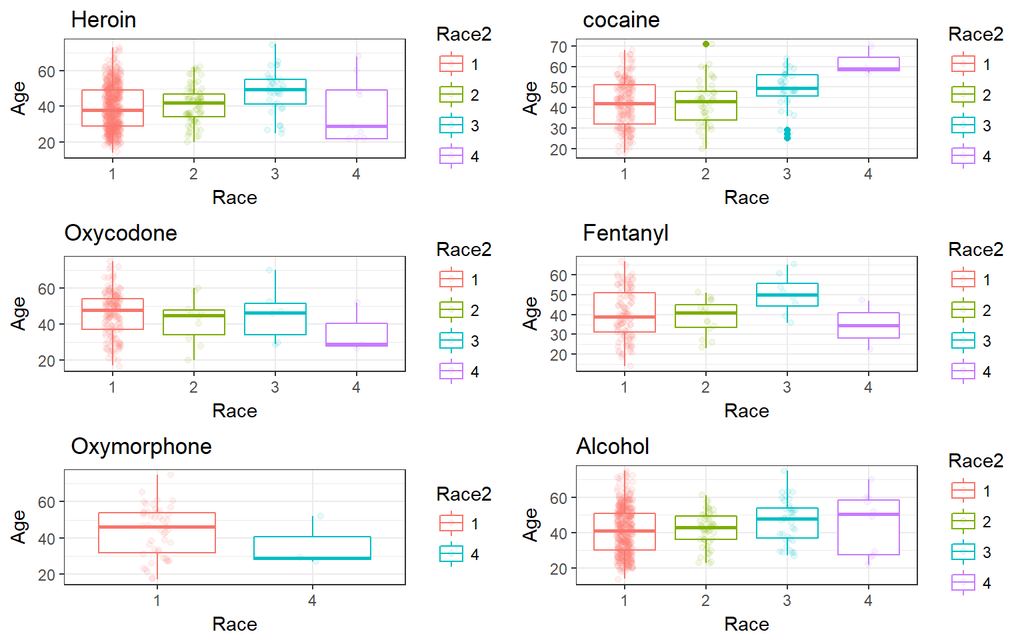

```r
P1<-ggplot(subset(project_1F, Heroin != "N"),aes(x=Race2, y=Age, color=Race2))+
  geom_boxplot()+
  geom_jitter(position = position_jitter(width=0.1), alpha=0.1)+
  labs(title= " Heroin",
       x="Race", y="Age")+
  theme_bw()
P2<-ggplot(subset(project_1F, Cocaine != "N"),aes(x=Race2, y=Age, color=Race2))+
  geom_boxplot()+
  geom_jitter(position = position_jitter(width=0.1), alpha=0.1)+
  labs(title= " cocaine",
       x="Race", y="Age")+
  theme_bw()
P3<-ggplot(subset(project_1F, Oxycodone != "N"),aes(x=Race2, y=Age, color=Race2))+
  geom_boxplot()+
  geom_jitter(position = position_jitter(width = 0.1),alpha=0.1)+
  labs(title= "Oxycodone",
       x="Race", y="Age")+
  theme_bw()
P4<-ggplot(subset(project_1F, Fentanyl != "N"),aes(x=Race2, y=Age, color=Race2))+
  geom_boxplot()+
  geom_jitter(position = position_jitter(width=0.1),alpha=0.1)+
  labs(title= " Fentanyl",
       x="Race", y="Age")+
  theme_bw()
P5<-ggplot(subset(project_1F, Oxymorphone != "N"),aes(x=Race2, y=Age, color=Race2))+
  geom_boxplot()+
  geom_jitter(position = position_jitter(width=0.1),alpha=0.1)+
  labs(title= " Oxymorphone",
       x="Race", y="Age")+
        theme_bw()
P6<-ggplot(subset(project_1F, Alcohol != "N"),aes(x=Race2, y=Age, color=Race2))+
  geom_boxplot()+
  geom_jitter(position = position_jitter(width=0.1), alpha=0.1)+
  labs(title= "Alcohol",
       x="Race", y="Age")+
        theme_bw()
gridExtra::grid.arrange(P1, P2, P3, P4,P5,P6)
```

Above plot indicates that Heroin overdose related deaths are more common among Race=1 (white), while oxymorphone overdose related deaths are completely absent in Race=2 (white, Hispanic) and Race=3 (Black). Overall, drug overdose related accidents are more common in white or white hispanic race in this dataset.

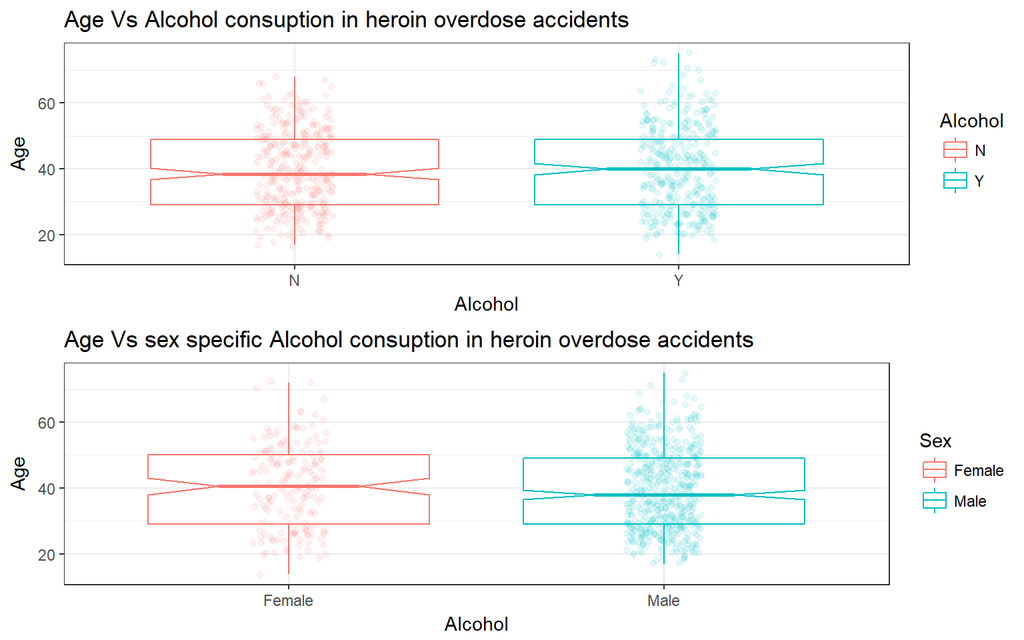

```r
P7<-ggplot(subset(project_1F, Heroin != "N"),aes(x=Alcohol, y=Age, color=Alcohol))+
  geom_boxplot(notch = TRUE)+
  geom_jitter(position = position_jitter(width=0.1), alpha=0.1)+
  labs(title= "Age Vs Alcohol consuption in heroin overdose accidents",
       x="Alcohol", y="Age")+
        theme_bw()
P8<-ggplot(subset(project_1F, Heroin != "N"),aes(x=Sex, y=Age, color=Sex))+
  geom_boxplot(notch = TRUE)+
  geom_jitter(position = position_jitter(width=0.1), alpha=0.1)+
  labs(title= "Age Vs sex specific Alcohol consuption in heroin overdose accidents",
       x="Alcohol", y="Age")+
        theme_bw()
gridExtra::grid.arrange(P7, P8)
```

```r
lm_model<-lm(Age~Race+Sex+Heroin+Cocaine+Fentanyl+Oxymorphone+Oxycodone+Alcohol, data=project_1F)
summary(lm_model)
```

```
Call:
lm(formula = Age ~ Race + Sex + Heroin + Cocaine + Fentanyl +
    Oxymorphone + Oxycodone + Alcohol, data = project_1F)

Residuals:
    Min      1Q  Median      3Q     Max
-26.590  -9.690   0.147   9.217  34.297

Coefficients:
                    Estimate Std. Error t value Pr(>|t|)
(Intercept)         48.25543    3.51834  13.715  < 2e-16 ***
RaceBlack            2.42575    3.60941   0.672  0.50170
RaceHispanic, White -2.10854    3.49836  -0.603  0.54683
RaceWhite           -2.94322    3.30013  -0.892  0.37269
SexMale             -1.79531    0.86364  -2.079  0.03789 *
HeroinY             -4.85147    0.96325  -5.037 5.63e-07 ***
CocaineY             1.03555    0.93334   1.110  0.26748
FentanylY           -1.83779    1.15854  -1.586  0.11299
OxymorphoneY        -2.53240    1.90044  -1.333  0.18299
OxycodoneY           3.07332    1.18825   2.586  0.00984 **
AlcoholY             0.03724    0.78267   0.048  0.96206
---
Signif. codes:  0 '***' 0.001 '**' 0.01 '*' 0.05 '.' 0.1 ' ' 1

Residual standard error: 12.16 on 988 degrees of freedom
Multiple R-squared:  0.07661,   Adjusted R-squared:  0.06726
F-statistic: 8.197 on 10 and 988 DF,  p-value: 7.672e-13
```

Kitchen sink model suggests oxycodone, heroin,sex are significant effect on output age.

```r
lmmodel_int<-lm(Age~Race*Heroin+Sex*Oxycodone+Cocaine+Fentanyl+Oxymorphone+Alcohol, data=project_1F)
summary(lmmodel_int)
```

```
Call:
lm(formula = Age ~ Race * Heroin + Sex * Oxycodone + Cocaine +
    Fentanyl + Oxymorphone + Alcohol, data = project_1F)

Residuals:
    Min      1Q  Median      3Q     Max
-25.786  -9.728   0.161   9.054  34.322

Coefficients:
                             Estimate Std. Error t value Pr(>|t|)
(Intercept)                  54.05170    5.63297   9.596  < 2e-16 ***
RaceBlack                    -7.36670    5.87118  -1.255  0.20988
RaceHispanic, White         -10.10013    5.91117  -1.709  0.08783 .
RaceWhite                    -8.64698    5.52319  -1.566  0.11777
HeroinY                     -14.19842    6.82404  -2.081  0.03772 *
SexMale                      -1.10127    0.95685  -1.151  0.25004
OxycodoneY                    5.49921    1.86596   2.947  0.00328 **
CocaineY                      1.09743    0.93218   1.177  0.23937
FentanylY                    -1.70650    1.15499  -1.478  0.13986
OxymorphoneY                 -3.07021    1.89991  -1.616  0.10642
AlcoholY                      0.02636    0.78214   0.034  0.97312
RaceBlack:HeroinY            16.16046    7.41470   2.180  0.02953 *
RaceHispanic, White:HeroinY  11.78660    7.29662   1.615  0.10656
RaceWhite:HeroinY             8.54647    6.85817   1.246  0.21300
SexMale:OxycodoneY           -4.01713    2.11917  -1.896  0.05830 .
---
Signif. codes:  0 '***' 0.001 '**' 0.01 '*' 0.05 '.' 0.1 ' ' 1

Residual standard error: 12.11 on 984 degrees of freedom
Multiple R-squared:  0.08797,   Adjusted R-squared:  0.075
F-statistic:  6.78 on 14 and 984 DF,  p-value: 2.288e-13
```

```r
anova(lm_model,lmmodel_int)
```

```
Analysis of Variance Table

Model 1: Age ~ Race + Sex + Heroin + Cocaine + Fentanyl + Oxymorphone +
    Oxycodone + Alcohol
Model 2: Age ~ Race * Heroin + Sex * Oxycodone + Cocaine + Fentanyl +
    Oxymorphone + Alcohol
  Res.Df    RSS Df Sum of Sq      F  Pr(>F)
1    988 146190
2    984 144390  4    1799.8 3.0664 0.01591 *
---
Signif. codes:  0 '***' 0.001 '**' 0.01 '*' 0.05 '.' 0.1 ' ' 1
```

Two models were built one model without interaction and another model with interaction term. Interaction between Heroin and race and sex and oxycodone has significant impact in the model, which accounted for 8% variation. Overall interaction costs 4 degrees of freedom. Unfortunately, R square of the model is not very impressive.

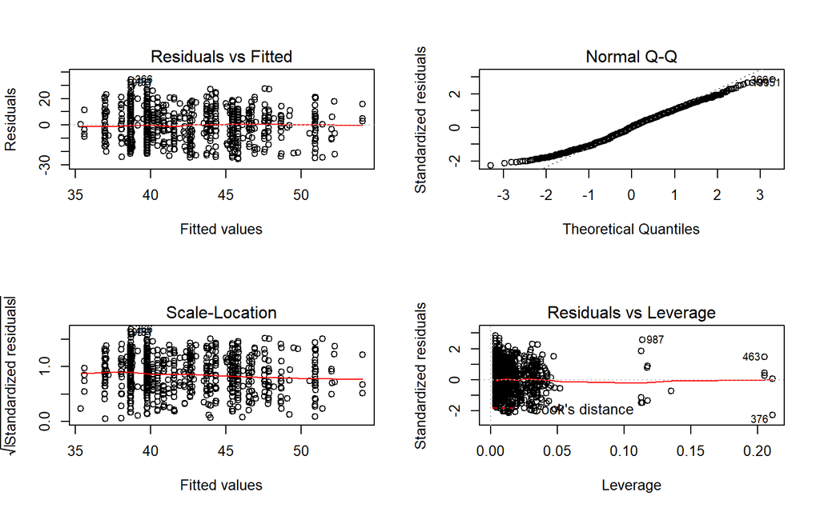

```r
par(mfrow = c(2, 2))
plot(lmmodel_int)
```

Above plot indicate model with interaction has slight problem with equal variance and normality. To improve and simplify the model predictor selection was performed.

```r
library(leaps)
```

```r
bs_preds <- with(project_1F,
                 cbind(Race,Sex,Heroin,Cocaine,Oxymorphone,Oxycodone,Alcohol))
bs_subs <- regsubsets(bs_preds,
      y = project_1F$Age,
      nvmax = 6)
bs_mods <- summary(bs_subs)
bs_mods$which
```

```
  (Intercept)  Race   Sex Heroin Cocaine Oxymorphone Oxycodone Alcohol
1        TRUE FALSE FALSE   TRUE   FALSE       FALSE     FALSE   FALSE
2        TRUE  TRUE FALSE   TRUE   FALSE       FALSE     FALSE   FALSE
3        TRUE  TRUE FALSE   TRUE   FALSE       FALSE      TRUE   FALSE
4        TRUE  TRUE  TRUE   TRUE   FALSE       FALSE      TRUE   FALSE
5        TRUE  TRUE  TRUE   TRUE    TRUE       FALSE      TRUE   FALSE
6        TRUE  TRUE  TRUE   TRUE    TRUE        TRUE      TRUE   FALSE
```

```r
aic.c <- 325 * log( bs_mods$rss / 325) + 2 * 2:7 +
                      (2 * 2:7 * (2:7 + 1) / (325 - 2:7 - 1))
best_mods_1 <- data_frame(
    k = 2:7,
    r2 = bs_mods$rsq,
    adjr2 = bs_mods$adjr2,
    cp = bs_mods$cp,
    aic.c = aic.c,
    bic = bs_mods$bic
)

best_mods <- cbind(best_mods_1, bs_mods$which)

best_mods
```

```
  k         r2      adjr2        cp    aic.c       bic (Intercept)  Race
1 2 0.05050404 0.04955168 18.627158 1998.469 -37.95867        TRUE FALSE
2 3 0.05879369 0.05690372 11.777601 1997.657 -39.81206        TRUE  TRUE
3 4 0.06382162 0.06099897  8.410074 1997.966 -38.25627        TRUE  TRUE
4 5 0.06804728 0.06429696  5.899006 1998.559 -35.86894        TRUE  TRUE
5 6 0.06998323 0.06530037  5.832293 1999.959 -31.03958        TRUE  TRUE
6 7 0.07165713 0.06604215  6.045338 2001.463 -25.93250        TRUE  TRUE
    Sex Heroin Cocaine Oxymorphone Oxycodone Alcohol
1 FALSE   TRUE   FALSE       FALSE     FALSE   FALSE
2 FALSE   TRUE   FALSE       FALSE     FALSE   FALSE
3 FALSE   TRUE   FALSE       FALSE      TRUE   FALSE
4  TRUE   TRUE   FALSE       FALSE      TRUE   FALSE
5  TRUE   TRUE    TRUE       FALSE      TRUE   FALSE
6  TRUE   TRUE    TRUE        TRUE      TRUE   FALSE
```

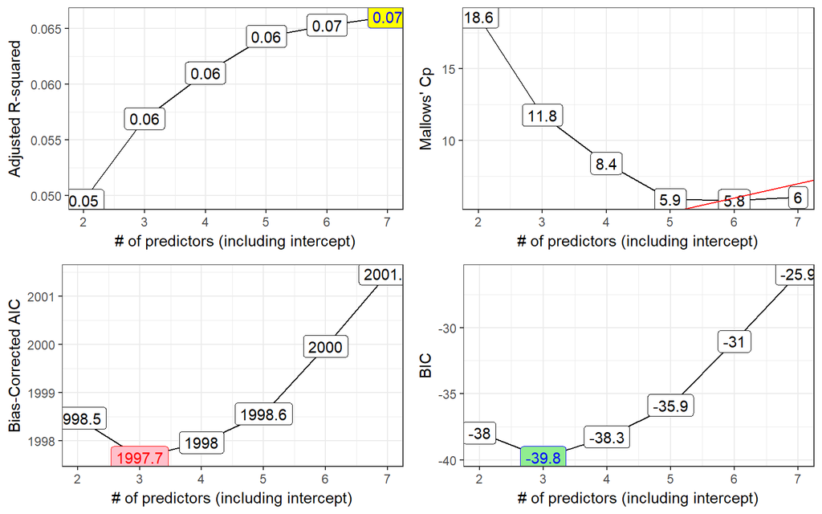

```r
p1 <- ggplot(best_mods, aes(x = k, y = adjr2,
                            label = round(adjr2,2))) +
    geom_line() +
    geom_label() +
    geom_label(data = subset(best_mods,
                             adjr2 == max(adjr2)),
               aes(x = k, y = adjr2, label = round(adjr2,2)),
               fill = "yellow", col = "blue") +
    theme_bw() +
    scale_x_continuous(breaks = 2:8) +
    labs(x = "# of predictors (including intercept)",
         y = "Adjusted R-squared")
p2 <- ggplot(best_mods, aes(x = k, y = cp,
                            label = round(cp,1))) +
    geom_line() +
    geom_label() +
    geom_abline(intercept = 0, slope = 1,
                col = "red") +
    theme_bw() +
    scale_x_continuous(breaks = 2:8) +
    labs(x = "# of predictors (including intercept)",
         y = "Mallows' Cp")
p3 <- ggplot(best_mods, aes(x = k, y = aic.c,
                             label = round(aic.c,1))) +
    geom_line() +
    geom_label() +
    geom_label(data = subset(best_mods, aic.c == min(aic.c)),
               aes(x = k, y = aic.c), fill = "pink",
               col = "red") +
    theme_bw() +
    scale_x_continuous(breaks = 2:8) +
    labs(x = "# of predictors (including intercept)",
         y = "Bias-Corrected AIC")
p4 <- ggplot(best_mods, aes(x = k, y = bic,
                            label = round(bic,1))) +
    geom_line() +
    geom_label() +
    geom_label(data = subset(best_mods, bic == min(bic)),
               aes(x = k, y = bic),
               fill = "lightgreen", col = "blue") +
    theme_bw() +
    scale_x_continuous(breaks = 2:8) +
    labs(x = "# of predictors (including intercept)",
         y = "BIC")
gridExtra::grid.arrange(p1, p2, p3, p4, nrow = 2)
```

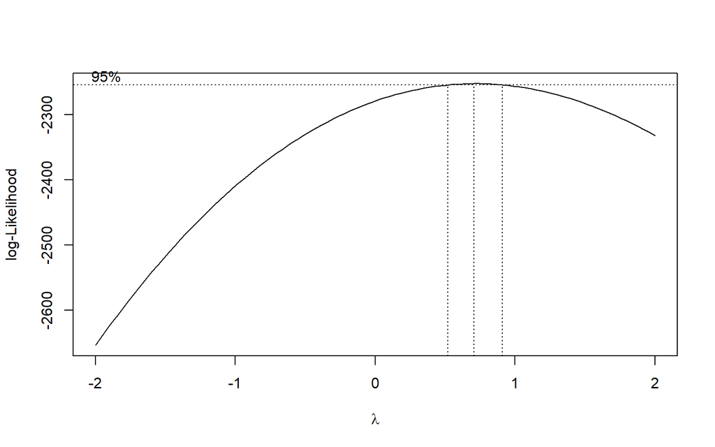

```r
boxcox(lmmodel_int)
```

```r
glance(lmmodel_int)
```

```
   r.squared adj.r.squared    sigma statistic      p.value df    logLik
1 0.08797498    0.07499902 12.11355  6.779841 2.288337e-13 15 -3901.793
       AIC      BIC deviance df.residual
1 7835.586 7914.095 144390.3         984
```

All models have two interaction terms Race(interaction)Heroin and Sex(interaction)Oxycodone

lmmodel_int-:Age~ Race(interaction)Heroin, Sex(interaction)Oxycodone, Oxymorphone, Alcohol,Cocaine model-6-: Age~Race(interaction)Heroin, Sex(interaction)Oxycodone, Cocaine model-3-: Age~Race(interaction)Heroin,oxycodone

All above models were tested to make prediction as follows.

```r
set.seed(432)
final1pre <- project_1F %>%
crossv_kfold(k = 10) %>%
mutate(model = map(train, ~ lm(Age~Race*Heroin+Sex*Oxycodone+Cocaine+Fentanyl+Oxymorphone+Alcohol
, data = .)))
finalpred <- final1pre %>%
unnest(map2(model, test, ~ augment(.x, newdata = .y)))
head(finalpred)
```

```
# A tibble: 6 x 15
    .id CaseNumber       Date    Sex                Race   Age Heroin
  <chr>      <chr>      <chr> <fctr>              <fctr> <int> <fctr>
1    01   12-18447 12/29/2012   Male               White    30      N
2    01   13-18018 12/10/2013 Female               White    45      Y
3    01   13-14650  10/8/2013   Male Asian,other,unknown    60      Y
4    01   15-10732  6/30/2015   Male               White    20      N
5    01   13-15629 10/27/2013   Male               White    30      Y
6    01   15-14958  9/18/2015   Male               White    23      Y
# ... with 8 more variables: Cocaine <fctr>, Fentanyl <fctr>,
#   Oxycodone <fctr>, Oxymorphone <fctr>, Alcohol <fctr>, Race2 <fctr>,
#   .fitted <dbl>, .se.fit <dbl>
```

```r
final_pred<- finalpred %>%
summarize(Model = "lmmodel_int",
RMSE = sqrt(mean((Age - .fitted) ^2)),
MAE = mean(abs(Age - .fitted)))
final_pred
```

```
# A tibble: 1 x 3
        Model     RMSE      MAE
        <chr>    <dbl>    <dbl>
1 lmmodel_int 12.25237 10.22187
```

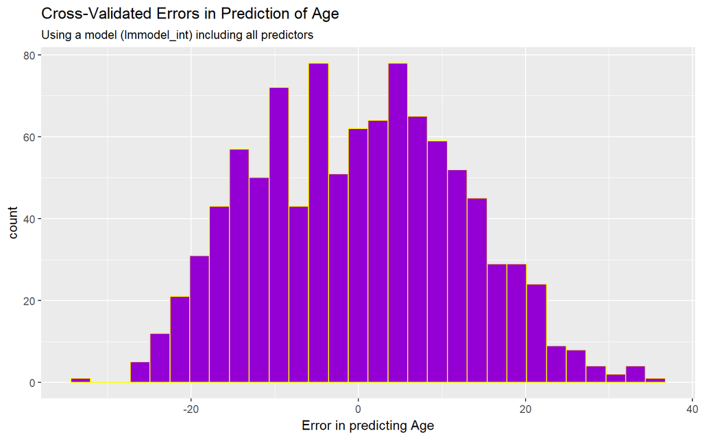

```r
finalpred %>%
    mutate(errors = Age - .fitted) %>%
    ggplot(., aes(x = errors)) +
    geom_histogram(bins = 30, fill = "darkviolet", col = "yellow") +
    labs(title = "Cross-Validated Errors in Prediction of Age",
         subtitle = "Using a model (lmmodel_int) including all predictors",
         x = "Error in predicting Age")
```

Further to understand how well this model makes prediction, 10 fold cross validation was performed, which gave high root mean squared prediction error = 12.2 and mean absolute prediction error = 10.2.Overall this model did not show better prediction of Age when all predictors Race,Heroin,Sex, Alcohol, Cocaine,Fentanyl,Oxymorphone,Oxycodone are accounted for.

Based on above plots and mellow’s Cp statistics model-6 without alcohol and oxymorphone predictors were built if this new model will give better prediction of age.

```r
lmmod_6<-lm(Age~Race*Heroin+Sex*Oxycodone+Cocaine+Fentanyl, data=project_1F)
summary(lmmod_6)
```

```
Call:
lm(formula = Age ~ Race * Heroin + Sex * Oxycodone + Cocaine +
    Fentanyl, data = project_1F)

Residuals:
    Min      1Q  Median      3Q     Max
-26.021  -9.722  -0.052   8.870  34.392

Coefficients:
                            Estimate Std. Error t value Pr(>|t|)
(Intercept)                  53.0376     5.5385   9.576  < 2e-16 ***
RaceBlack                    -6.2968     5.8259  -1.081  0.28004
RaceHispanic, White          -9.0459     5.8637  -1.543  0.12322
RaceWhite                    -7.8635     5.4939  -1.431  0.15266
HeroinY                     -13.4344     6.7984  -1.976  0.04842 *
SexMale                      -1.1529     0.9555  -1.207  0.22790
OxycodoneY                    4.9557     1.8257   2.714  0.00675 **
CocaineY                      1.1720     0.9269   1.264  0.20638
FentanylY                    -1.6177     1.1465  -1.411  0.15858
RaceBlack:HeroinY            15.3775     7.3931   2.080  0.03778 *
RaceHispanic, White:HeroinY  11.0460     7.2737   1.519  0.12918
RaceWhite:HeroinY             8.0213     6.8463   1.172  0.24163
SexMale:OxycodoneY           -3.9254     2.1154  -1.856  0.06380 .
---
Signif. codes:  0 '***' 0.001 '**' 0.01 '*' 0.05 '.' 0.1 ' ' 1

Residual standard error: 12.12 on 986 degrees of freedom
Multiple R-squared:  0.08555,   Adjusted R-squared:  0.07443
F-statistic: 7.687 on 12 and 986 DF,  p-value: 9.094e-14
```

```r
set.seed(432)
final1pre_2 <- project_1F %>%
crossv_kfold(k = 10) %>%
mutate(model = map(train, ~ lm(Age~Race*Heroin+Sex*Oxycodone+Cocaine+Fentanyl
, data = .)))
finalpred_2 <- final1pre_2 %>%
unnest(map2(model, test, ~ augment(.x, newdata = .y)))
head(finalpred_2)
```

```
# A tibble: 6 x 15
    .id CaseNumber       Date    Sex                Race   Age Heroin
  <chr>      <chr>      <chr> <fctr>              <fctr> <int> <fctr>
1    01   12-18447 12/29/2012   Male               White    30      N
2    01   13-18018 12/10/2013 Female               White    45      Y
3    01   13-14650  10/8/2013   Male Asian,other,unknown    60      Y
4    01   15-10732  6/30/2015   Male               White    20      N
5    01   13-15629 10/27/2013   Male               White    30      Y
6    01   15-14958  9/18/2015   Male               White    23      Y
# ... with 8 more variables: Cocaine <fctr>, Fentanyl <fctr>,
#   Oxycodone <fctr>, Oxymorphone <fctr>, Alcohol <fctr>, Race2 <fctr>,
#   .fitted <dbl>, .se.fit <dbl>
```

```r
final_pred_2<- finalpred_2 %>%
summarize(Model = "lmmod_6",
RMSE = sqrt(mean((Age - .fitted) ^2)),
MAE = mean(abs(Age - .fitted)))
final_pred_2
```

```
# A tibble: 1 x 3
    Model     RMSE      MAE
    <chr>    <dbl>    <dbl>
1 lmmod_6 12.23916 10.21155
```

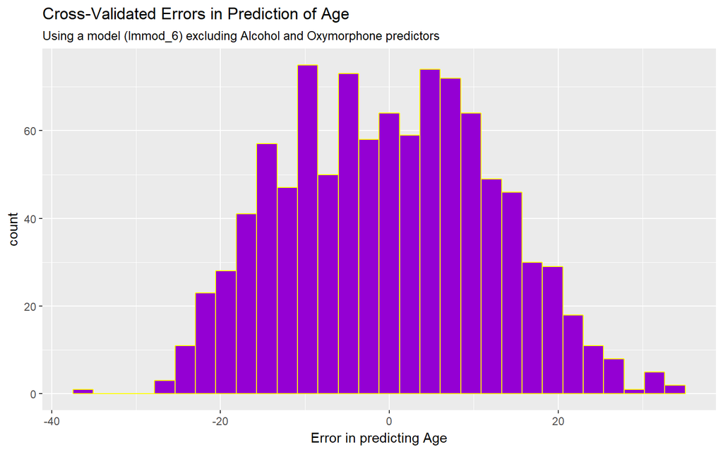

```r
finalpred_2 %>%
    mutate(errors = Age - .fitted) %>%
    ggplot(., aes(x = errors)) +
    geom_histogram(bins = 30, fill = "darkviolet", col = "yellow") +
    labs(title = "Cross-Validated Errors in Prediction of Age",
         subtitle = "Using a model (lmmod_6) excluding Alcohol and Oxymorphone predictors",
         x = "Error in predicting Age")
```

```r
lmmod_3<-lm(Age~Race*Heroin+Oxycodone, data=project_1F)
summary(lmmod_3)
```

```
Call:
lm(formula = Age ~ Race * Heroin + Oxycodone, data = project_1F)

Residuals:
    Min      1Q  Median      3Q     Max
-27.381  -9.960   0.310   9.254  34.040

Coefficients:
                            Estimate Std. Error t value Pr(>|t|)
(Intercept)                   52.079      5.460   9.539   <2e-16 ***
RaceBlack                     -5.418      5.835  -0.929   0.3533
RaceHispanic, White           -8.441      5.872  -1.438   0.1509
RaceWhite                     -7.389      5.496  -1.345   0.1791
HeroinY                      -14.002      6.794  -2.061   0.0396 *
OxycodoneY                     2.302      1.113   2.068   0.0389 *
RaceBlack:HeroinY             15.390      7.403   2.079   0.0379 *
RaceHispanic, White:HeroinY   11.109      7.282   1.526   0.1274
RaceWhite:HeroinY              8.272      6.850   1.208   0.2275
---
Signif. codes:  0 '***' 0.001 '**' 0.01 '*' 0.05 '.' 0.1 ' ' 1

Residual standard error: 12.17 on 990 degrees of freedom
Multiple R-squared:  0.07424,   Adjusted R-squared:  0.06676
F-statistic: 9.923 on 8 and 990 DF,  p-value: 2.363e-13
```

```r
set.seed(432)
final1pre_3 <- project_1F %>%
crossv_kfold(k = 10) %>%
mutate(model = map(train, ~ lm(Age~Race*Heroin+Oxycodone
, data = .)))
finalpred_3 <- final1pre_3 %>%
unnest(map2(model, test, ~ augment(.x, newdata = .y)))
head(finalpred_3)
```

```
# A tibble: 6 x 15
    .id CaseNumber       Date    Sex                Race   Age Heroin
  <chr>      <chr>      <chr> <fctr>              <fctr> <int> <fctr>
1    01   12-18447 12/29/2012   Male               White    30      N
2    01   13-18018 12/10/2013 Female               White    45      Y
3    01   13-14650  10/8/2013   Male Asian,other,unknown    60      Y
4    01   15-10732  6/30/2015   Male               White    20      N
5    01   13-15629 10/27/2013   Male               White    30      Y
6    01   15-14958  9/18/2015   Male               White    23      Y
# ... with 8 more variables: Cocaine <fctr>, Fentanyl <fctr>,
#   Oxycodone <fctr>, Oxymorphone <fctr>, Alcohol <fctr>, Race2 <fctr>,
#   .fitted <dbl>, .se.fit <dbl>
```

```r
final_pred_3<- finalpred_3 %>%
summarize(Model = "lmmod_3",
RMSE = sqrt(mean((Age - .fitted) ^2)),
MAE = mean(abs(Age - .fitted)))
final_pred_3
```

```
# A tibble: 1 x 3
    Model     RMSE      MAE
    <chr>    <dbl>    <dbl>
1 lmmod_3 12.28977 10.25239
```

Tenfold cross validation followed by age prediction using three different models kitchen sink with interaction, model-6 and model-3 show high root mean squared prediction error = 12.25, 12.23,12.28, respectively. Mean absolute prediction error = 10.22, 10.21, 10.25 for kitchen sink with interaction, model-6 and model-3 respectively.

```r
lm_final<-ols(Age~Race*Heroin+Sex*Oxycodone+Cocaine+Fentanyl, x=TRUE,y=TRUE, data=project_1F)
lm_final
```

```
Linear Regression Model

 ols(formula = Age ~ Race * Heroin + Sex * Oxycodone + Cocaine +
     Fentanyl, data = project_1F, x = TRUE, y = TRUE)

                 Model Likelihood     Discrimination
                    Ratio Test           Indexes
 Obs      999    LR chi2     89.35    R2       0.086
 sigma12.1173    d.f.           12    R2 adj   0.074
 d.f.     986    Pr(> chi2) 0.0000    g        3.954

 Residuals

       Min        1Q    Median        3Q       Max
 -26.02120  -9.72185  -0.05155   8.87019  34.39192


                                 Coef     S.E.   t     Pr(>|t|)
 Intercept                        53.0376 5.5385  9.58 <0.0001
 Race=Black                       -6.2968 5.8259 -1.08 0.2800
 Race=Hispanic, White             -9.0459 5.8637 -1.54 0.1232
 Race=White                       -7.8635 5.4939 -1.43 0.1527
 Heroin=Y                        -13.4344 6.7984 -1.98 0.0484
 Sex=Male                         -1.1529 0.9555 -1.21 0.2279
 Oxycodone=Y                       4.9557 1.8257  2.71 0.0068
 Cocaine=Y                         1.1720 0.9269  1.26 0.2064
 Fentanyl=Y                       -1.6177 1.1465 -1.41 0.1586
 Race=Black * Heroin=Y            15.3775 7.3931  2.08 0.0378
 Race=Hispanic, White * Heroin=Y  11.0460 7.2737  1.52 0.1292
 Race=White * Heroin=Y             8.0213 6.8463  1.17 0.2416
 Sex=Male * Oxycodone=Y           -3.9254 2.1154 -1.86 0.0638
```

```r
validate(lm_final)
```

```
          index.orig training     test optimism index.corrected  n
R-square      0.0856   0.0989   0.0717   0.0272          0.0583 40
MSE         144.9185 142.0701 147.1141  -5.0440        149.9625 40
g             3.9535   4.1746   3.6434   0.5312          3.4223 40
Intercept     0.0000   0.0000   5.2370  -5.2370          5.2370 40
Slope         1.0000   1.0000   0.8744   0.1256          0.8744 40
```

In the new data above model will account for 5.8% variation and 149.96 MSE.

```r
summary(lmmod_6)
```

```
Call:
lm(formula = Age ~ Race * Heroin + Sex * Oxycodone + Cocaine +
    Fentanyl, data = project_1F)

Residuals:
    Min      1Q  Median      3Q     Max
-26.021  -9.722  -0.052   8.870  34.392

Coefficients:
                            Estimate Std. Error t value Pr(>|t|)
(Intercept)                  53.0376     5.5385   9.576  < 2e-16 ***
RaceBlack                    -6.2968     5.8259  -1.081  0.28004
RaceHispanic, White          -9.0459     5.8637  -1.543  0.12322
RaceWhite                    -7.8635     5.4939  -1.431  0.15266
HeroinY                     -13.4344     6.7984  -1.976  0.04842 *
SexMale                      -1.1529     0.9555  -1.207  0.22790
OxycodoneY                    4.9557     1.8257   2.714  0.00675 **
CocaineY                      1.1720     0.9269   1.264  0.20638
FentanylY                    -1.6177     1.1465  -1.411  0.15858
RaceBlack:HeroinY            15.3775     7.3931   2.080  0.03778 *
RaceHispanic, White:HeroinY  11.0460     7.2737   1.519  0.12918
RaceWhite:HeroinY             8.0213     6.8463   1.172  0.24163
SexMale:OxycodoneY           -3.9254     2.1154  -1.856  0.06380 .
---
Signif. codes:  0 '***' 0.001 '**' 0.01 '*' 0.05 '.' 0.1 ' ' 1

Residual standard error: 12.12 on 986 degrees of freedom
Multiple R-squared:  0.08555,   Adjusted R-squared:  0.07443
F-statistic: 7.687 on 12 and 986 DF,  p-value: 9.094e-14
```

Final Equation-:

Age= 53.03(intercept)-6.29(Black)-9.04(White,Hispanic)-7.86(white)-13(Heroin)-1.15(male)+4.95(oxycodone)+1.15(cocaine)-1.61(Fentanyl)+15.37(Black:heroinY)+8.02(white:HeroinY)-3.9(male:OxycodoneY)

# 11 Task-11 Logistic Regression Model

Here I will predict the binary outcome Alcohol using some combination of the following seven variables:

1. Race
2. Sex
3. Heroin
4. cocaine
5. Fentanyl
6. Oxycodone
7. Oxymorphone

In this model, I want to compare odds of alcohol in different drug overdose groups. Therefore, I choose not to eliminate the predictors from the model.

First I need to mutate the factor Heroin,cocaine,Fentanyl,Oxycodone,Oxymorphone into binary 0 = no drug and 1= specified drug overdose.

```r
project_1F_New <- project_1F %>%
    mutate(
        Alcohol = factor(case_when(
            Alcohol == "Y" ~ "1",
            Alcohol =="N"~"0")))
```

```r
project_1F_New <-project_1F_New %>%
    mutate(
        Heroin = factor(case_when(
            Heroin == "Y" ~ "1",
            Heroin =="N"~"0")))
```

```r
project_1F_New <- project_1F_New %>%
    mutate(
        Fentanyl = factor(case_when(
            Fentanyl == "Y" ~ "1",
            Fentanyl =="N"~"0")))
```

```r
project_1F_New <- project_1F_New %>%
    mutate(
        Oxycodone = factor(case_when(
            Oxycodone == "Y" ~ "1",
            Oxycodone =="N"~"0")))
```

```r
project_1F_New <- project_1F_New %>%
    mutate(
        Oxymorphone = factor(case_when(
            Oxymorphone == "Y" ~ "1",
            Oxymorphone =="N"~"0")))
```

```r
project_1F_New <- project_1F_New %>%
    mutate(
        Cocaine = factor(case_when(
            Cocaine == "Y" ~ "1",
            Cocaine =="N"~"0")))
project_1F_New
```

```
# A tibble: 999 x 12
   CaseNumber       Date    Sex            Race   Age Heroin Cocaine
        <chr>      <chr> <fctr>          <fctr> <int> <fctr>  <fctr>
 1   13-16336  11/9/2013 Female           White    53      0       0
 2   12-18447 12/29/2012   Male           White    30      0       1
 3    14-2758  2/18/2014   Male           White    43      0       0
 4   14-13497   9/7/2014 Female           White    24      1       0
 5   13-14421  10/4/2013 Female           White    26      1       0
 6   13-18018 12/10/2013 Female           White    45      1       0
 7   13-19004 12/27/2013   Male           White    55      1       0
 8    13-3783   3/4/2013   Male Hispanic, White    47      1       1
 9    14-5669   4/9/2014 Female           White    53      0       1
10    13-9675  6/28/2013   Male           White    29      1       0
# ... with 989 more rows, and 5 more variables: Fentanyl <fctr>,
#   Oxycodone <fctr>, Oxymorphone <fctr>, Alcohol <fctr>, Race2 <fctr>
```

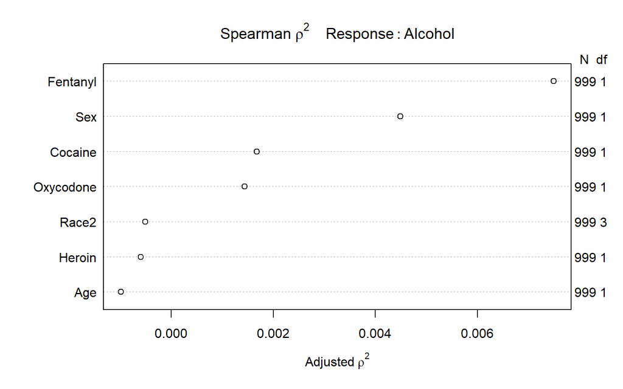

```r
plot(spearman2(Alcohol~Heroin+Age+Race2+Sex+Heroin+Cocaine+Oxycodone+Fentanyl, data=project_1F_New))
```

According to plot above predictors Fentanyl and sex are important variables. I want to evaluate if sex and fentanyl interaction is significant.

```r
logic_Int_lr<-lrm(Alcohol~Heroin+Age+Heroin+Race2+Cocaine+Oxycodone+Sex*Fentanyl, x=TRUE,y=TRUE, data = project_1F_New)
logic_Int_lr
```

```
Logistic Regression Model

 lrm(formula = Alcohol ~ Heroin + Age + Heroin + Race2 + Cocaine +
     Oxycodone + Sex * Fentanyl, data = project_1F_New, x = TRUE,
     y = TRUE)

                      Model Likelihood     Discrimination    Rank Discrim.
                         Ratio Test           Indexes           Indexes
 Obs           999    LR chi2     32.34    R2       0.042    C       0.595
  0            483    d.f.           10    g        0.400    Dxy     0.190
  1            516    Pr(> chi2) 0.0004    gr       1.492    gamma   0.204
 max |deriv| 5e-12                         gp       0.097    tau-a   0.095
                                           Brier    0.242

                       Coef    S.E.   Wald Z Pr(>|Z|)
 Intercept              0.3744 0.3088  1.21  0.2253
 Heroin=1              -0.4357 0.1631 -2.67  0.0076
 Age                    0.0002 0.0053  0.03  0.9763
 Race2=2                0.0165 0.2166  0.08  0.9392
 Race2=3                0.0986 0.2644  0.37  0.7092
 Race2=4                0.7860 0.6024  1.30  0.1920
 Cocaine=1             -0.4693 0.1564 -3.00  0.0027
 Oxycodone=1           -0.5662 0.1939 -2.92  0.0035
 Sex=Male               0.4050 0.1537  2.64  0.0084
 Fentanyl=1            -0.5609 0.3707 -1.51  0.1303
 Sex=Male * Fentanyl=1 -0.2037 0.4300 -0.47  0.6356
```

```r
anova(logic_Int_lr)
```

```
                Wald Statistics          Response: Alcohol

 Factor                                        Chi-Square d.f. P
 Heroin                                         7.13       1   0.0076
 Age                                            0.00       1   0.9763
 Race2                                          1.81       3   0.6124
 Cocaine                                        9.00       1   0.0027
 Oxycodone                                      8.52       1   0.0035
 Sex  (Factor+Higher Order Factors)             7.17       2   0.0277
  All Interactions                              0.22       1   0.6356
 Fentanyl  (Factor+Higher Order Factors)       13.26       2   0.0013
  All Interactions                              0.22       1   0.6356
 Sex * Fentanyl  (Factor+Higher Order Factors)  0.22       1   0.6356
 TOTAL                                         30.61      10   0.0007
```

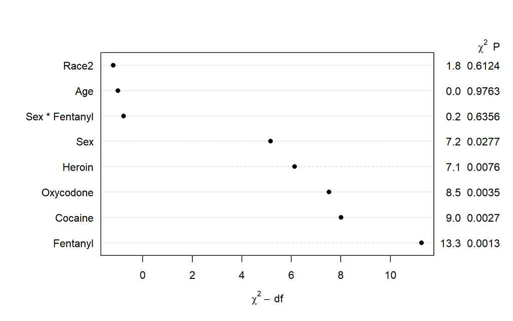

```r
plot(anova(logic_Int_lr))
```

The interaction between sex and fentanyl is not significant according to the anova statistics. Therefore, model without interaction is considered to predict the alcohol as output.

```r
logic_lr<-lrm(Alcohol~Heroin+Age+Heroin+Race2+Cocaine+Oxycodone+Sex+Fentanyl, x=TRUE,y=TRUE, data = project_1F_New)
logic_lr
```

```
Logistic Regression Model

 lrm(formula = Alcohol ~ Heroin + Age + Heroin + Race2 + Cocaine +
     Oxycodone + Sex + Fentanyl, data = project_1F_New, x = TRUE,
     y = TRUE)

                      Model Likelihood     Discrimination    Rank Discrim.
                         Ratio Test           Indexes           Indexes
 Obs           999    LR chi2     32.12    R2       0.042    C       0.595
  0            483    d.f.            9    g        0.399    Dxy     0.189
  1            516    Pr(> chi2) 0.0002    gr       1.490    gamma   0.206
 max |deriv| 1e-11                         gp       0.097    tau-a   0.095
                                           Brier    0.242

             Coef    S.E.   Wald Z Pr(>|Z|)
 Intercept    0.3949 0.3058  1.29  0.1967
 Heroin=1    -0.4382 0.1631 -2.69  0.0072
 Age          0.0001 0.0053  0.02  0.9807
 Race2=2      0.0232 0.2162  0.11  0.9145
 Race2=3      0.1021 0.2643  0.39  0.6992
 Race2=4      0.7830 0.6017  1.30  0.1932
 Cocaine=1   -0.4702 0.1564 -3.01  0.0026
 Oxycodone=1 -0.5681 0.1939 -2.93  0.0034
 Sex=Male     0.3799 0.1442  2.63  0.0084
 Fentanyl=1  -0.7106 0.1969 -3.61  0.0003
```

Above summary indicates heroin, cocaine, oxycodone, sex and fentanyl are significantly associated with output alcohol overdose. overall this model is not very remarkable in making predictions since Nagelkerke R2 = 0.0422 and C = 0.595 which is as good as just guessing output alcohol randomly.

```r
set.seed(432001)
validate(logic_lr, B = 100)
```

```
          index.orig training   test optimism index.corrected   n
Dxy           0.1991   0.2133 0.1723   0.0410          0.1581 100
R2            0.0422   0.0532 0.0337   0.0195          0.0227 100
Intercept     0.0000   0.0000 0.0177  -0.0177          0.0177 100
Slope         1.0000   1.0000 0.7946   0.2054          0.7946 100
Emax          0.0000   0.0000 0.0542   0.0542          0.0542 100
D             0.0311   0.0397 0.0246   0.0152          0.0160 100
U            -0.0020  -0.0020 0.0018  -0.0038          0.0018 100
Q             0.0331   0.0418 0.0228   0.0190          0.0142 100
B             0.2419   0.2398 0.2442  -0.0045          0.2464 100
g             0.3988   0.4545 0.3551   0.0994          0.2994 100
gp            0.0967   0.1087 0.0864   0.0222          0.0745 100
```

In the new data this model will account for 2.27% variation with ROC= 0.595, which is not very impressive.

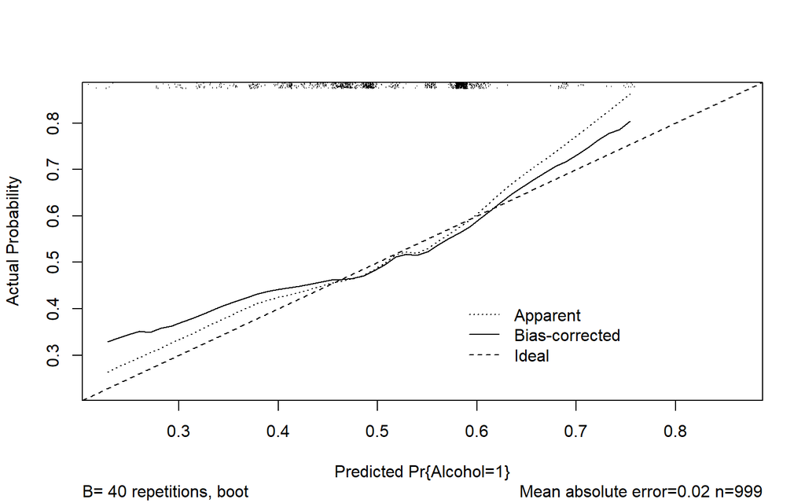

```
n=999   Mean absolute error=0.02   Mean squared error=0.00065
0.9 Quantile of absolute error=0.037
```

```r
plot(calibrate(logic_lr))
```

Model variate substantially when predicted probability of alcohol increases from 0.3 and 0.7. This model makes most of the probability of alcohol overdose is between 0.4 to 0.6, while there are not many predictions from 0.7 to 0.8.

```r
dd=datadist(project_1F_New)
options(datadist="dd")
summary(logic_lr)
```

```
             Effects              Response : Alcohol

 Factor            Low High Diff. Effect    S.E.    Lower 0.95 Upper 0.95
 Age               31  51   20     0.002576 0.10646 -0.20609    0.211240
  Odds Ratio       31  51   20     1.002600      NA  0.81376    1.235200
 Heroin - 0:1       2   1   NA     0.438200 0.16311  0.11850    0.757900
  Odds Ratio        2   1   NA     1.549900      NA  1.12580    2.133800
 Race2 - 2:1        1   2   NA     0.023223 0.21621 -0.40055    0.446990
  Odds Ratio        1   2   NA     1.023500      NA  0.66995    1.563600
 Race2 - 3:1        1   3   NA     0.102120 0.26434 -0.41597    0.620220
  Odds Ratio        1   3   NA     1.107500      NA  0.65970    1.859300
 Race2 - 4:1        1   4   NA     0.783010 0.60171 -0.39633    1.962300
  Odds Ratio        1   4   NA     2.188100      NA  0.67279    7.116000
 Cocaine - 1:0      1   2   NA    -0.470210 0.15637 -0.77669   -0.163730
  Odds Ratio        1   2   NA     0.624870      NA  0.45993    0.848970
 Oxycodone - 1:0    1   2   NA    -0.568070 0.19392 -0.94814   -0.187990
  Odds Ratio        1   2   NA     0.566620      NA  0.38746    0.828620
 Sex - Female:Male  2   1   NA    -0.379870 0.14420 -0.66250   -0.097242
  Odds Ratio        2   1   NA     0.683950      NA  0.51556    0.907340
 Fentanyl - 1:0     1   2   NA    -0.710560 0.19686 -1.09640   -0.324730
  Odds Ratio        1   2   NA     0.491370      NA  0.33407    0.722730
```

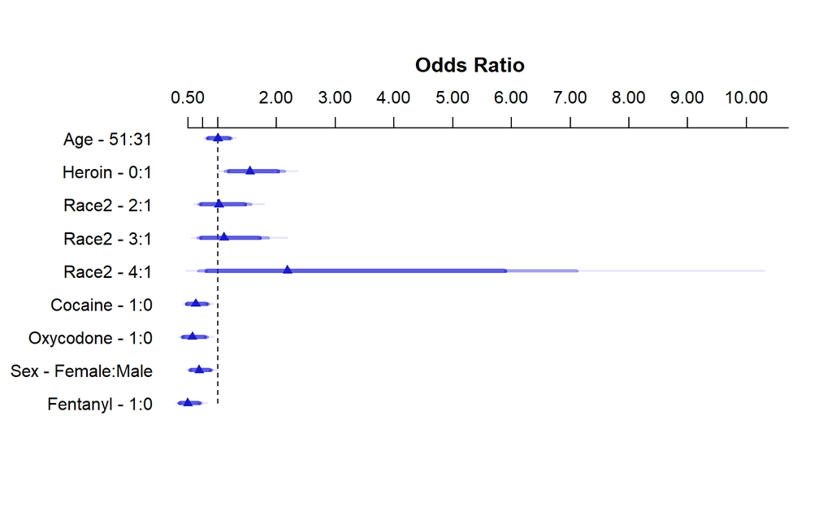

```r
dd=datadist(project_1F_New)
options(datadist="dd")
plot(summary(logic_lr))
```

# 12 Task 12a: Conclusions-1

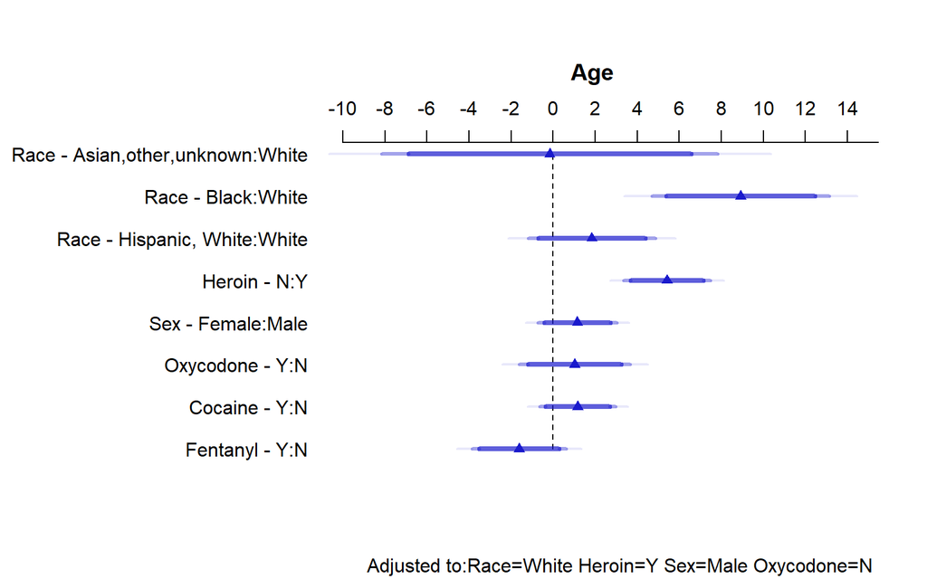

```r
dd=datadist(project_1F)
options(datadist="dd")
plot(summary(lm_final))
```

Above plot shows that race black has significantly higher age than white race in heroin overdose related accidents. Heroin overdose related accidents are commonly observed in 8 years older black (race) individuals compared to white individuals.

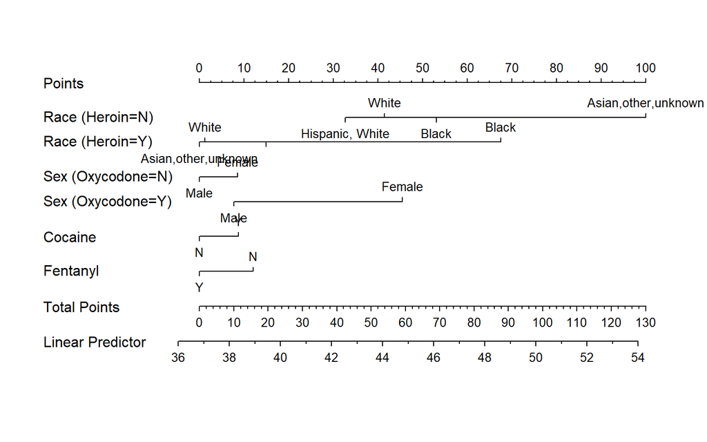

```r
dd=datadist(project_1F)
options(datadist="dd")
plot(nomogram(lm_final))
```

```r
glance(lm_final)
```

```
   r.squared adj.r.squared    sigma statistic      p.value df    logLik
1 0.08555443    0.07442528 12.11731  7.687415 9.094073e-14 13 -3903.117
       AIC      BIC df.residual
1 7834.234 7902.929         986
```

```r
head(final_pred_2)
```

```
# A tibble: 1 x 3
    Model     RMSE      MAE
    <chr>    <dbl>    <dbl>
1 lmmod_6 12.23916 10.21155
```

Overall, combination of all predictors in the dataset did not predict age with considerable accuracy. Final model accounted for 7.4% variation.However, this model gives idea that heroin addiction is race specific. Combination of other drugs with heroin are also significantly could alter the output age.

# 13 Task 12b: Conclusions-2

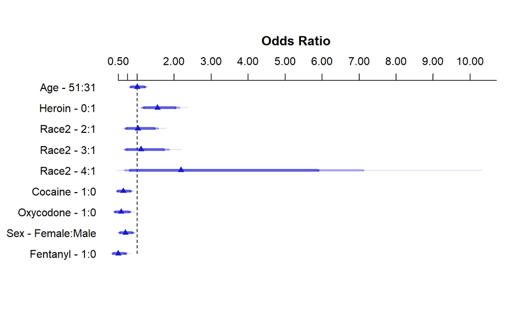

```r
dd=datadist(project_1F_New)
options(datadist="dd")
plot(summary(logic_lr))
```

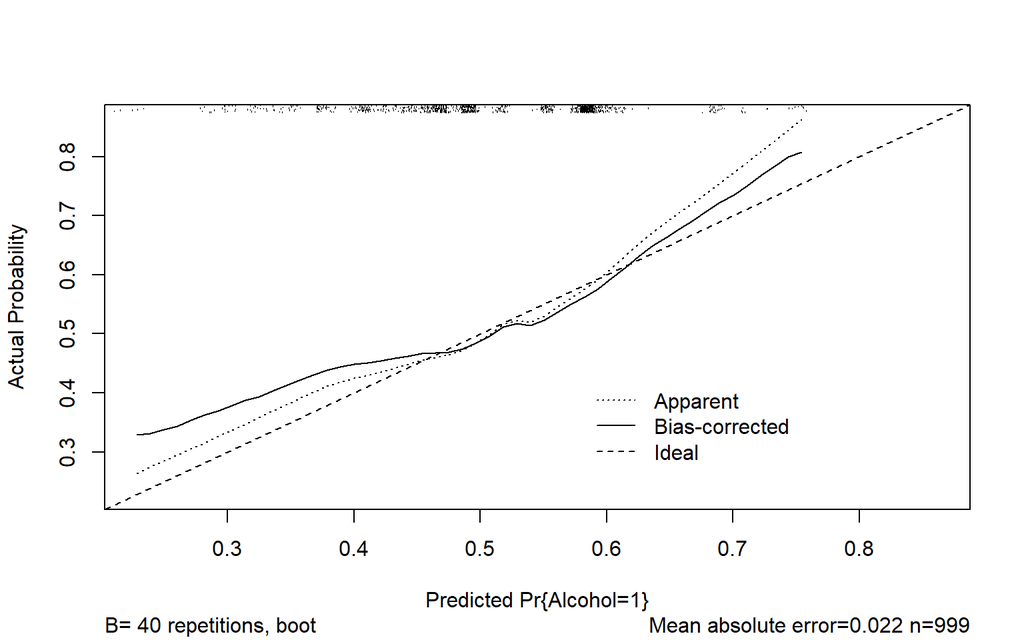

```
n=999   Mean absolute error=0.022   Mean squared error=0.00076
0.9 Quantile of absolute error=0.043
```

```r
plot(calibrate(logic_lr))
```

Final calibrated model shows a lot of variation when predicted probability of alcohol increases from 0.3. The model also shows variation at the higher end when probability of alcohol rises from 0.6 to 0.7.

This model makes most of the predictions of probability of alcohol overdose between 0.4 and 0.6, while there are not many predictions between 0.7 and 0.8. Overall, Final logistic model account for 4% variation with ROC=0.595.

Preeti Pathak

2018-03-23 13:12:29